# Risk Factor Analysis

## Outcome Variable

**Outcome Variable:** stunted

## Predictor Variables

**Intervention Variable:** nhh

**Adjustment Set:**

unadjusted

## Stratifying Variables

The analysis was stratified on these variable(s):

- agecat
- studyid

The following strata were considered:

- agecat: 12 months, studyid: ki1000108-IRC
- agecat: 12 months, studyid: ki1000304b-SAS-FoodSuppl
- agecat: 12 months, studyid: ki1017093-NIH-Birth
- agecat: 12 months, studyid: ki1017093b-PROVIDE
- agecat: 12 months, studyid: ki1017093c-NIH-Crypto
- agecat: 12 months, studyid: ki1148112-LCNI-5
- agecat: 18 months, studyid: ki1000108-IRC
- agecat: 18 months, studyid: ki1000304b-SAS-FoodSuppl
- agecat: 18 months, studyid: ki1017093-NIH-Birth
- agecat: 18 months, studyid: ki1017093b-PROVIDE
- agecat: 18 months, studyid: ki1017093c-NIH-Crypto
- agecat: 18 months, studyid: ki1148112-LCNI-5
- agecat: 24 months, studyid: ki1000108-IRC
- agecat: 24 months, studyid: ki1017093-NIH-Birth
- agecat: 24 months, studyid: ki1017093b-PROVIDE
- agecat: 24 months, studyid: ki1017093c-NIH-Crypto
- agecat: 24 months, studyid: ki1148112-LCNI-5
- agecat: 3 months, studyid: ki1000108-IRC
- agecat: 3 months, studyid: ki1000304b-SAS-FoodSuppl
- agecat: 3 months, studyid: ki1017093-NIH-Birth
- agecat: 3 months, studyid: ki1017093b-PROVIDE
- agecat: 3 months, studyid: ki1017093c-NIH-Crypto
- agecat: 6 months, studyid: ki1000108-IRC
- agecat: 6 months, studyid: ki1000304b-SAS-FoodSuppl
- agecat: 6 months, studyid: ki1017093-NIH-Birth
- agecat: 6 months, studyid: ki1017093b-PROVIDE
- agecat: 6 months, studyid: ki1017093c-NIH-Crypto
- agecat: 6 months, studyid: ki1148112-LCNI-5
- agecat: 9 months, studyid: ki1000108-IRC
- agecat: 9 months, studyid: ki1000304b-SAS-FoodSuppl
- agecat: 9 months, studyid: ki1017093-NIH-Birth
- agecat: 9 months, studyid: ki1017093b-PROVIDE
- agecat: 9 months, studyid: ki1017093c-NIH-Crypto
- agecat: 9 months, studyid: ki1148112-LCNI-5
- agecat: Birth, studyid: ki1000108-IRC
- agecat: Birth, studyid: ki1017093-NIH-Birth
- agecat: Birth, studyid: ki1017093c-NIH-Crypto

### Dropped Strata

Some strata were dropped due to rare outcomes:

- agecat: 12 months, studyid: ki1000304b-SAS-FoodSuppl
- agecat: 18 months, studyid: ki1000304b-SAS-FoodSuppl
- agecat: 3 months, studyid: ki1000304b-SAS-FoodSuppl
- agecat: 3 months, studyid: ki1017093b-PROVIDE
- agecat: 6 months, studyid: ki1000304b-SAS-FoodSuppl
- agecat: 6 months, studyid: ki1017093b-PROVIDE
- agecat: 9 months, studyid: ki1000304b-SAS-FoodSuppl
- agecat: 9 months, studyid: ki1017093b-PROVIDE
- agecat: Birth, studyid: ki1000108-IRC
- agecat: Birth, studyid: ki1017093-NIH-Birth
- agecat: Birth, studyid: ki1017093c-NIH-Crypto

## Methods Detail

We’re interested in the causal parameters $E[Y_a]$ for all values of $a \in \mathcal{A}$. These parameters represent the mean outcome if, possibly contrary to fact, we intervened to set all units to have $A=a$. Under the randomization and positivity assumptions, these are identified by the statistical parameters $\psi_a=E_W[E_{Y|A,W}(Y|A=a,W)]$. In addition, we’re interested in the mean of $Y$, $E[Y]$ under no intervention (the observed mean). We will estimate these parameters by using SuperLearner to fit the relevant likelihood factors – $E_{Y|A,W}(Y|A=a,W)$ and $p(A=a|W)$, and then updating our likelihood fit using a joint TMLE.

For unadjusted analyses ($W=\{\}$), initial likelihoods were estimated using Lrnr_glm to estimate the simple $E(Y|A)$ and Lrnr_mean to estimate $p(A)$. For adjusted analyses, a small library containing Lrnr_glmnet, Lrnr_xgboost, and Lrnr_mean was used.

Having estimated these parameters, we will then use the delta method to estimate relative risks and attributable risks relative to a prespecified baseline level of $A$.

# Results Detail

## Results Plots

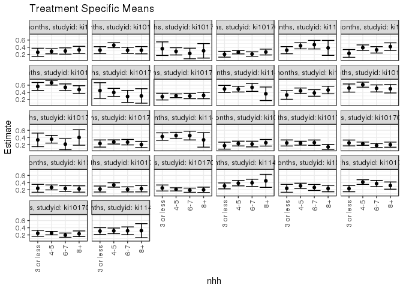

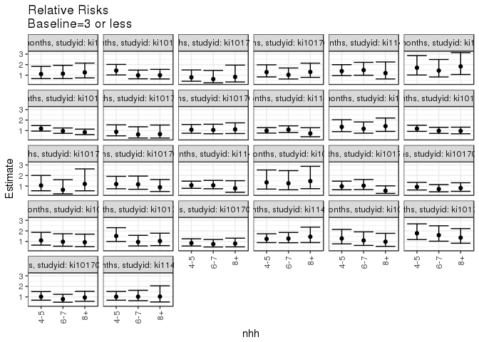

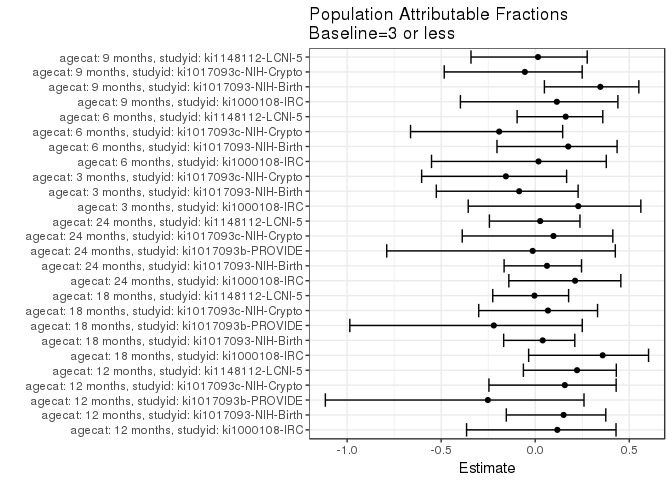

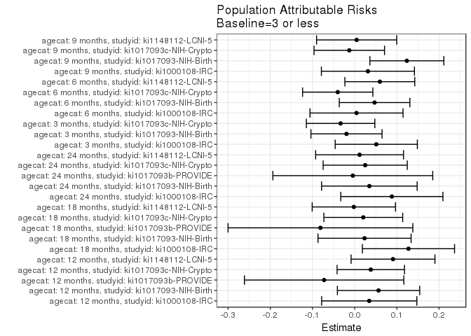

## Data Summary

| agecat | studyid | A | n | nA | nAY0 | nAY1 |
| --- | --- | --- | --- | --- | --- | --- |
| 12 months | ki1000108-IRC | 3 or less | 406 | 58 | 43 | 15 |
| 12 months | ki1000108-IRC | 4-5 | 406 | 157 | 112 | 45 |
| 12 months | ki1000108-IRC | 6-7 | 406 | 105 | 74 | 31 |
| 12 months | ki1000108-IRC | 8+ | 406 | 86 | 58 | 28 |
| 12 months | ki1000304b-SAS-FoodSuppl | 3 or less | 92 | 7 | 3 | 4 |
| 12 months | ki1000304b-SAS-FoodSuppl | 4-5 | 92 | 36 | 6 | 30 |
| 12 months | ki1000304b-SAS-FoodSuppl | 6-7 | 92 | 33 | 8 | 25 |
| 12 months | ki1000304b-SAS-FoodSuppl | 8+ | 92 | 16 | 2 | 14 |
| 12 months | ki1017093-NIH-Birth | 3 or less | 491 | 88 | 60 | 28 |
| 12 months | ki1017093-NIH-Birth | 4-5 | 491 | 206 | 112 | 94 |
| 12 months | ki1017093-NIH-Birth | 6-7 | 491 | 115 | 79 | 36 |
| 12 months | ki1017093-NIH-Birth | 8+ | 491 | 82 | 56 | 26 |
| 12 months | ki1017093b-PROVIDE | 3 or less | 153 | 25 | 16 | 9 |
| 12 months | ki1017093b-PROVIDE | 4-5 | 153 | 77 | 55 | 22 |
| 12 months | ki1017093b-PROVIDE | 6-7 | 153 | 31 | 24 | 7 |
| 12 months | ki1017093b-PROVIDE | 8+ | 153 | 20 | 14 | 6 |
| 12 months | ki1017093c-NIH-Crypto | 3 or less | 706 | 98 | 78 | 20 |
| 12 months | ki1017093c-NIH-Crypto | 4-5 | 706 | 324 | 239 | 85 |
| 12 months | ki1017093c-NIH-Crypto | 6-7 | 706 | 171 | 135 | 36 |
| 12 months | ki1017093c-NIH-Crypto | 8+ | 706 | 113 | 83 | 30 |
| 12 months | ki1148112-LCNI-5 | 3 or less | 306 | 85 | 58 | 27 |
| 12 months | ki1148112-LCNI-5 | 4-5 | 306 | 132 | 74 | 58 |
| 12 months | ki1148112-LCNI-5 | 6-7 | 306 | 68 | 36 | 32 |
| 12 months | ki1148112-LCNI-5 | 8+ | 306 | 21 | 13 | 8 |
| 18 months | ki1000108-IRC | 3 or less | 405 | 57 | 44 | 13 |
| 18 months | ki1000108-IRC | 4-5 | 405 | 157 | 96 | 61 |
| 18 months | ki1000108-IRC | 6-7 | 405 | 107 | 72 | 35 |
| 18 months | ki1000108-IRC | 8+ | 405 | 84 | 49 | 35 |
| 18 months | ki1000304b-SAS-FoodSuppl | 3 or less | 84 | 6 | 1 | 5 |
| 18 months | ki1000304b-SAS-FoodSuppl | 4-5 | 84 | 32 | 1 | 31 |

[output cut: 138 more lines]

## Results Table

### Parameter: TSM

| agecat | studyid | intervention_level | baseline_level | estimate | ci_lower | ci_upper |
| --- | --- | --- | --- | --- | --- | --- |
| 12 months | ki1000108-IRC | 3 or less | NA | 0.2586207 | 0.1457915 | 0.3714499 |
| 12 months | ki1000108-IRC | 4-5 | NA | 0.2866242 | 0.2158053 | 0.3574431 |
| 12 months | ki1000108-IRC | 6-7 | NA | 0.2952381 | 0.2078814 | 0.3825948 |
| 12 months | ki1000108-IRC | 8+ | NA | 0.3255814 | 0.2264231 | 0.4247397 |
| 12 months | ki1017093-NIH-Birth | 3 or less | NA | 0.3181818 | 0.2207678 | 0.4155958 |
| 12 months | ki1017093-NIH-Birth | 4-5 | NA | 0.4563107 | 0.3882239 | 0.5243975 |
| 12 months | ki1017093-NIH-Birth | 6-7 | NA | 0.3130435 | 0.2282019 | 0.3978851 |
| 12 months | ki1017093-NIH-Birth | 8+ | NA | 0.3170732 | 0.2162522 | 0.4178941 |
| 12 months | ki1017093b-PROVIDE | 3 or less | NA | 0.3600000 | 0.1712255 | 0.5487745 |
| 12 months | ki1017093b-PROVIDE | 4-5 | NA | 0.2857143 | 0.1844798 | 0.3869488 |
| 12 months | ki1017093b-PROVIDE | 6-7 | NA | 0.2258065 | 0.0781392 | 0.3734737 |
| 12 months | ki1017093b-PROVIDE | 8+ | NA | 0.3000000 | 0.0985039 | 0.5014961 |
| 12 months | ki1017093c-NIH-Crypto | 3 or less | NA | 0.2040816 | 0.1242309 | 0.2839324 |
| 12 months | ki1017093c-NIH-Crypto | 4-5 | NA | 0.2623457 | 0.2144113 | 0.3102800 |
| 12 months | ki1017093c-NIH-Crypto | 6-7 | NA | 0.2105263 | 0.1493787 | 0.2716740 |
| 12 months | ki1017093c-NIH-Crypto | 8+ | NA | 0.2654867 | 0.1840092 | 0.3469643 |
| 12 months | ki1148112-LCNI-5 | 3 or less | NA | 0.3176471 | 0.2185122 | 0.4167819 |
| 12 months | ki1148112-LCNI-5 | 4-5 | NA | 0.4393939 | 0.3545877 | 0.5242002 |
| 12 months | ki1148112-LCNI-5 | 6-7 | NA | 0.4705882 | 0.3517594 | 0.5894170 |
| 12 months | ki1148112-LCNI-5 | 8+ | NA | 0.3809524 | 0.1729125 | 0.5889923 |
| 18 months | ki1000108-IRC | 3 or less | NA | 0.2280702 | 0.1190089 | 0.3371315 |
| 18 months | ki1000108-IRC | 4-5 | NA | 0.3885350 | 0.3121979 | 0.4648722 |
| 18 months | ki1000108-IRC | 6-7 | NA | 0.3271028 | 0.2380988 | 0.4161068 |
| 18 months | ki1000108-IRC | 8+ | NA | 0.4166667 | 0.3111070 | 0.5222263 |
| 18 months | ki1017093-NIH-Birth | 3 or less | NA | 0.5641026 | 0.4539381 | 0.6742670 |
| 18 months | ki1017093-NIH-Birth | 4-5 | NA | 0.6683673 | 0.6023853 | 0.7343494 |
| 18 months | ki1017093-NIH-Birth | 6-7 | NA | 0.5412844 | 0.4476385 | 0.6349303 |
| 18 months | ki1017093-NIH-Birth | 8+ | NA | 0.4750000 | 0.3654534 | 0.5845466 |
| 18 months | ki1017093b-PROVIDE | 3 or less | NA | 0.4500000 | 0.2311905 | 0.6688095 |
| 18 months | ki1017093b-PROVIDE | 4-5 | NA | 0.3972603 | 0.2846094 | 0.5099112 |

[output cut: 74 more lines]

### Parameter: E(Y)

| agecat | studyid | intervention_level | baseline_level | estimate | ci_lower | ci_upper |
| --- | --- | --- | --- | --- | --- | --- |
| 12 months | ki1000108-IRC | NA | NA | 0.2931034 | 0.2911297 | 0.2950772 |
| 12 months | ki1017093-NIH-Birth | NA | NA | 0.3747454 | 0.3686035 | 0.3808873 |
| 12 months | ki1017093b-PROVIDE | NA | NA | 0.2875817 | 0.2811201 | 0.2940433 |
| 12 months | ki1017093c-NIH-Crypto | NA | NA | 0.2422096 | 0.2402321 | 0.2441872 |
| 12 months | ki1148112-LCNI-5 | NA | NA | 0.4084967 | 0.4017507 | 0.4152428 |
| 18 months | ki1000108-IRC | NA | NA | 0.3555556 | 0.3496262 | 0.3614850 |
| 18 months | ki1017093-NIH-Birth | NA | NA | 0.5874730 | 0.5806797 | 0.5942663 |
| 18 months | ki1017093b-PROVIDE | NA | NA | 0.3687943 | 0.3591400 | 0.3784487 |
| 18 months | ki1017093c-NIH-Crypto | NA | NA | 0.3012618 | 0.3005168 | 0.3020068 |
| 18 months | ki1148112-LCNI-5 | NA | NA | 0.4929178 | 0.4885927 | 0.4972430 |
| 24 months | ki1000108-IRC | NA | NA | 0.4156479 | 0.4111175 | 0.4201783 |
| 24 months | ki1017093-NIH-Birth | NA | NA | 0.5547786 | 0.5498747 | 0.5596825 |
| 24 months | ki1017093b-PROVIDE | NA | NA | 0.3288591 | 0.3194722 | 0.3382460 |
| 24 months | ki1017093c-NIH-Crypto | NA | NA | 0.2568093 | 0.2544830 | 0.2591357 |
| 24 months | ki1148112-LCNI-5 | NA | NA | 0.4368601 | 0.4332423 | 0.4404779 |
| 3 months | ki1000108-IRC | NA | NA | 0.2235872 | 0.2212292 | 0.2259452 |
| 3 months | ki1017093-NIH-Birth | NA | NA | 0.2280702 | 0.2246838 | 0.2314565 |
| 3 months | ki1017093c-NIH-Crypto | NA | NA | 0.2142857 | 0.2125182 | 0.2160532 |
| 6 months | ki1000108-IRC | NA | NA | 0.2457002 | 0.2440501 | 0.2473504 |
| 6 months | ki1017093-NIH-Birth | NA | NA | 0.2681564 | 0.2633022 | 0.2730106 |
| 6 months | ki1017093c-NIH-Crypto | NA | NA | 0.2097902 | 0.2083934 | 0.2111870 |
| 6 months | ki1148112-LCNI-5 | NA | NA | 0.3679012 | 0.3638195 | 0.3719830 |
| 9 months | ki1000108-IRC | NA | NA | 0.2727273 | 0.2696592 | 0.2757953 |
| 9 months | ki1017093-NIH-Birth | NA | NA | 0.3570020 | 0.3511840 | 0.3628200 |
| 9 months | ki1017093c-NIH-Crypto | NA | NA | 0.2322946 | 0.2305980 | 0.2339912 |
| 9 months | ki1148112-LCNI-5 | NA | NA | 0.3123028 | 0.3119558 | 0.3126499 |

### Parameter: RR

| agecat | studyid | intervention_level | baseline_level | estimate | ci_lower | ci_upper |
| --- | --- | --- | --- | --- | --- | --- |
| 12 months | ki1000108-IRC | 4-5 | 3 or less | 1.1082803 | 0.6712787 | 1.829769 |
| 12 months | ki1000108-IRC | 6-7 | 3 or less | 1.1415873 | 0.6738648 | 1.933951 |
| 12 months | ki1000108-IRC | 8+ | 3 or less | 1.2589147 | 0.7394776 | 2.143224 |
| 12 months | ki1017093-NIH-Birth | 4-5 | 3 or less | 1.4341193 | 1.0201683 | 2.016038 |
| 12 months | ki1017093-NIH-Birth | 6-7 | 3 or less | 0.9838509 | 0.6536623 | 1.480830 |
| 12 months | ki1017093-NIH-Birth | 8+ | 3 or less | 0.9965157 | 0.6408900 | 1.549476 |
| 12 months | ki1017093b-PROVIDE | 4-5 | 3 or less | 0.7936508 | 0.4214851 | 1.494434 |
| 12 months | ki1017093b-PROVIDE | 6-7 | 3 or less | 0.6272401 | 0.2712667 | 1.450345 |
| 12 months | ki1017093b-PROVIDE | 8+ | 3 or less | 0.8333333 | 0.3554294 | 1.953818 |
| 12 months | ki1017093c-NIH-Crypto | 4-5 | 3 or less | 1.2854938 | 0.8346978 | 1.979752 |
| 12 months | ki1017093c-NIH-Crypto | 6-7 | 3 or less | 1.0315789 | 0.6336864 | 1.679309 |
| 12 months | ki1017093c-NIH-Crypto | 8+ | 3 or less | 1.3008850 | 0.7911831 | 2.138951 |
| 12 months | ki1148112-LCNI-5 | 4-5 | 3 or less | 1.3832772 | 0.9583951 | 1.996521 |
| 12 months | ki1148112-LCNI-5 | 6-7 | 3 or less | 1.4814815 | 0.9916269 | 2.213320 |
| 12 months | ki1148112-LCNI-5 | 8+ | 3 or less | 1.1992945 | 0.6393784 | 2.249540 |
| 18 months | ki1000108-IRC | 4-5 | 3 or less | 1.7035767 | 1.0158734 | 2.856826 |
| 18 months | ki1000108-IRC | 6-7 | 3 or less | 1.4342200 | 0.8273190 | 2.486329 |
| 18 months | ki1000108-IRC | 8+ | 3 or less | 1.8269231 | 1.0634058 | 3.138640 |
| 18 months | ki1017093-NIH-Birth | 4-5 | 3 or less | 1.1848330 | 0.9519681 | 1.474660 |
| 18 months | ki1017093-NIH-Birth | 6-7 | 3 or less | 0.9595496 | 0.7391948 | 1.245593 |
| 18 months | ki1017093-NIH-Birth | 8+ | 3 or less | 0.8420455 | 0.6224301 | 1.139149 |
| 18 months | ki1017093b-PROVIDE | 4-5 | 3 or less | 0.8828006 | 0.5028089 | 1.549967 |
| 18 months | ki1017093b-PROVIDE | 6-7 | 3 or less | 0.6349206 | 0.2960996 | 1.361448 |
| 18 months | ki1017093b-PROVIDE | 8+ | 3 or less | 0.6666667 | 0.2908916 | 1.527870 |
| 18 months | ki1017093c-NIH-Crypto | 4-5 | 3 or less | 1.0850685 | 0.7456569 | 1.578975 |
| 18 months | ki1017093c-NIH-Crypto | 6-7 | 3 or less | 1.0609272 | 0.7018720 | 1.603663 |
| 18 months | ki1017093c-NIH-Crypto | 8+ | 3 or less | 1.1168627 | 0.7196399 | 1.733342 |
| 18 months | ki1148112-LCNI-5 | 4-5 | 3 or less | 0.9901338 | 0.7654334 | 1.280797 |
| 18 months | ki1148112-LCNI-5 | 6-7 | 3 or less | 1.0879121 | 0.8169583 | 1.448731 |
| 18 months | ki1148112-LCNI-5 | 8+ | 3 or less | 0.7273469 | 0.4154473 | 1.273407 |
| 24 months | ki1000108-IRC | 4-5 | 3 or less | 1.3524317 | 0.8988331 | 2.034940 |
| 24 months | ki1000108-IRC | 6-7 | 3 or less | 1.1697000 | 0.7528014 | 1.817475 |
| 24 months | ki1000108-IRC | 8+ | 3 or less | 1.4198286 | 0.9205382 | 2.189929 |
| 24 months | ki1017093-NIH-Birth | 4-5 | 3 or less | 1.1810201 | 0.9234239 | 1.510475 |
| 24 months | ki1017093-NIH-Birth | 6-7 | 3 or less | 0.9807692 | 0.7335145 | 1.311369 |
| 24 months | ki1017093-NIH-Birth | 8+ | 3 or less | 0.9615385 | 0.6982244 | 1.324153 |
| 24 months | ki1017093b-PROVIDE | 4-5 | 3 or less | 1.0519481 | 0.5522299 | 2.003866 |
| 24 months | ki1017093b-PROVIDE | 6-7 | 3 or less | 0.6428571 | 0.2586758 | 1.597619 |
| 24 months | ki1017093b-PROVIDE | 8+ | 3 or less | 1.2000000 | 0.5487017 | 2.624377 |
| 24 months | ki1017093c-NIH-Crypto | 4-5 | 3 or less | 1.1896552 | 0.7377339 | 1.918415 |
| 24 months | ki1017093c-NIH-Crypto | 6-7 | 3 or less | 1.1610577 | 0.6937899 | 1.943031 |
| 24 months | ki1017093c-NIH-Crypto | 8+ | 3 or less | 0.8832831 | 0.4828221 | 1.615894 |
| 24 months | ki1148112-LCNI-5 | 4-5 | 3 or less | 1.0687961 | 0.7813930 | 1.461909 |
| 24 months | ki1148112-LCNI-5 | 6-7 | 3 or less | 1.0654561 | 0.7403087 | 1.533410 |
| 24 months | ki1148112-LCNI-5 | 8+ | 3 or less | 0.7837838 | 0.4077674 | 1.506538 |
| 3 months | ki1000108-IRC | 4-5 | 3 or less | 1.3384615 | 0.7105541 | 2.521243 |
| 3 months | ki1000108-IRC | 6-7 | 3 or less | 1.2584906 | 0.6435488 | 2.461038 |
| 3 months | ki1000108-IRC | 8+ | 3 or less | 1.4666667 | 0.7501839 | 2.867445 |
| 3 months | ki1017093-NIH-Birth | 4-5 | 3 or less | 0.9722822 | 0.6467500 | 1.461666 |
| 3 months | ki1017093-NIH-Birth | 6-7 | 3 or less | 1.0327820 | 0.6603122 | 1.615355 |
| 3 months | ki1017093-NIH-Birth | 8+ | 3 or less | 0.5528421 | 0.3005755 | 1.016831 |
| 3 months | ki1017093c-NIH-Crypto | 4-5 | 3 or less | 0.9175084 | 0.6254671 | 1.345909 |
| 3 months | ki1017093c-NIH-Crypto | 6-7 | 3 or less | 0.7166338 | 0.4518869 | 1.136488 |
| 3 months | ki1017093c-NIH-Crypto | 8+ | 3 or less | 0.8074074 | 0.4970260 | 1.311615 |
| 6 months | ki1000108-IRC | 4-5 | 3 or less | 1.1012658 | 0.6512357 | 1.862285 |
| 6 months | ki1000108-IRC | 6-7 | 3 or less | 0.9770889 | 0.5518536 | 1.729993 |
| 6 months | ki1000108-IRC | 8+ | 3 or less | 0.9260504 | 0.5056838 | 1.695861 |
| 6 months | ki1017093-NIH-Birth | 4-5 | 3 or less | 1.5145794 | 0.9951004 | 2.305246 |
| 6 months | ki1017093-NIH-Birth | 6-7 | 3 or less | 0.9542411 | 0.5757728 | 1.581485 |
| 6 months | ki1017093-NIH-Birth | 8+ | 3 or less | 1.0399562 | 0.6063976 | 1.783498 |
| 6 months | ki1017093c-NIH-Crypto | 4-5 | 3 or less | 0.8466258 | 0.5711563 | 1.254954 |
| 6 months | ki1017093c-NIH-Crypto | 6-7 | 3 or less | 0.7529412 | 0.4769027 | 1.188755 |
| 6 months | ki1017093c-NIH-Crypto | 8+ | 3 or less | 0.8000000 | 0.4877826 | 1.312060 |
| 6 months | ki1148112-LCNI-5 | 4-5 | 3 or less | 1.2429196 | 0.8932931 | 1.729386 |
| 6 months | ki1148112-LCNI-5 | 6-7 | 3 or less | 1.2754327 | 0.8787962 | 1.851087 |
| 6 months | ki1148112-LCNI-5 | 8+ | 3 or less | 1.4538677 | 0.8949577 | 2.361823 |
| 9 months | ki1000108-IRC | 4-5 | 3 or less | 1.2848101 | 0.7694226 | 2.145423 |
| 9 months | ki1000108-IRC | 6-7 | 3 or less | 1.0943396 | 0.6271860 | 1.909448 |
| 9 months | ki1000108-IRC | 8+ | 3 or less | 0.9747899 | 0.5368070 | 1.770125 |
| 9 months | ki1017093-NIH-Birth | 4-5 | 3 or less | 1.7774852 | 1.1833158 | 2.670000 |
| 9 months | ki1017093-NIH-Birth | 6-7 | 3 or less | 1.5980630 | 1.0271355 | 2.486337 |
| 9 months | ki1017093-NIH-Birth | 8+ | 3 or less | 1.3588850 | 0.8311992 | 2.221571 |
| 9 months | ki1017093c-NIH-Crypto | 4-5 | 3 or less | 1.0168224 | 0.6883022 | 1.502142 |
| 9 months | ki1017093c-NIH-Crypto | 6-7 | 3 or less | 0.7873684 | 0.4977904 | 1.245402 |
| 9 months | ki1017093c-NIH-Crypto | 8+ | 3 or less | 0.9471429 | 0.5864600 | 1.529652 |
| 9 months | ki1148112-LCNI-5 | 4-5 | 3 or less | 1.0186567 | 0.6843030 | 1.516377 |
| 9 months | ki1148112-LCNI-5 | 6-7 | 3 or less | 1.0214286 | 0.6421690 | 1.624676 |
| 9 months | ki1148112-LCNI-5 | 8+ | 3 or less | 1.0340909 | 0.5207397 | 2.053510 |

### Parameter: PAR

| agecat | studyid | intervention_level | baseline_level | estimate | ci_lower | ci_upper |
| --- | --- | --- | --- | --- | --- | --- |
| 12 months | ki1000108-IRC | 3 or less | NA | 0.0344828 | -0.0783637 | 0.1473292 |
| 12 months | ki1017093-NIH-Birth | 3 or less | NA | 0.0565636 | -0.0410438 | 0.1541710 |
| 12 months | ki1017093b-PROVIDE | 3 or less | NA | -0.0724183 | -0.2613033 | 0.1164667 |
| 12 months | ki1017093c-NIH-Crypto | 3 or less | NA | 0.0381280 | -0.0417472 | 0.1180032 |
| 12 months | ki1148112-LCNI-5 | 3 or less | NA | 0.0908497 | -0.0085144 | 0.1902138 |
| 18 months | ki1000108-IRC | 3 or less | NA | 0.1274854 | 0.0182630 | 0.2367077 |
| 18 months | ki1017093-NIH-Birth | 3 or less | NA | 0.0233704 | -0.0870033 | 0.1337442 |
| 18 months | ki1017093b-PROVIDE | 3 or less | NA | -0.0812057 | -0.3002281 | 0.1378167 |
| 18 months | ki1017093c-NIH-Crypto | 3 or less | NA | 0.0203630 | -0.0730871 | 0.1138130 |
| 18 months | ki1148112-LCNI-5 | 3 or less | NA | -0.0020316 | -0.1007531 | 0.0966898 |
| 24 months | ki1000108-IRC | 3 or less | NA | 0.0880617 | -0.0329567 | 0.2090801 |
| 24 months | ki1017093-NIH-Birth | 3 or less | NA | 0.0347786 | -0.0785276 | 0.1480847 |
| 24 months | ki1017093b-PROVIDE | 3 or less | NA | -0.0044743 | -0.1939407 | 0.1849921 |
| 24 months | ki1017093c-NIH-Crypto | 3 or less | NA | 0.0249253 | -0.0747789 | 0.1246295 |
| 24 months | ki1148112-LCNI-5 | 3 or less | NA | 0.0115727 | -0.0925534 | 0.1156988 |
| 3 months | ki1000108-IRC | 3 or less | NA | 0.0511734 | -0.0461883 | 0.1485352 |
| 3 months | ki1017093-NIH-Birth | 3 or less | NA | -0.0194546 | -0.1037637 | 0.0648546 |
| 3 months | ki1017093c-NIH-Crypto | 3 or less | NA | -0.0334207 | -0.1145353 | 0.0476938 |
| 6 months | ki1000108-IRC | 3 or less | NA | 0.0043209 | -0.1059546 | 0.1145965 |
| 6 months | ki1017093-NIH-Birth | 3 or less | NA | 0.0471038 | -0.0365576 | 0.1307652 |
| 6 months | ki1017093c-NIH-Crypto | 3 or less | NA | -0.0402098 | -0.1235006 | 0.0430810 |
| 6 months | ki1148112-LCNI-5 | 3 or less | NA | 0.0595679 | -0.0232608 | 0.1423966 |
| 9 months | ki1000108-IRC | 3 or less | NA | 0.0313480 | -0.0789579 | 0.1416539 |
| 9 months | ki1017093-NIH-Birth | 3 or less | NA | 0.1236686 | 0.0360078 | 0.2113295 |
| 9 months | ki1017093c-NIH-Crypto | 3 or less | NA | -0.0128034 | -0.0963561 | 0.0707493 |
| 9 months | ki1148112-LCNI-5 | 3 or less | NA | 0.0046105 | -0.0903677 | 0.0995888 |

### Parameter: PAF

| agecat | studyid | intervention_level | baseline_level | estimate | ci_lower | ci_upper |
| --- | --- | --- | --- | --- | --- | --- |
| 12 months | ki1000108-IRC | 3 or less | NA | 0.1176471 | -0.3650099 | 0.4296402 |
| 12 months | ki1017093-NIH-Birth | 3 or less | NA | 0.1509387 | -0.1536984 | 0.3751356 |
| 12 months | ki1017093b-PROVIDE | 3 or less | NA | -0.2518182 | -1.1158396 | 0.2593726 |
| 12 months | ki1017093c-NIH-Crypto | 3 or less | NA | 0.1574174 | -0.2461644 | 0.4302955 |
| 12 months | ki1148112-LCNI-5 | 3 or less | NA | 0.2224000 | -0.0628828 | 0.4311115 |
| 18 months | ki1000108-IRC | 3 or less | NA | 0.3585526 | -0.0350548 | 0.6024803 |
| 18 months | ki1017093-NIH-Birth | 3 or less | NA | 0.0397813 | -0.1677039 | 0.2103992 |
| 18 months | ki1017093b-PROVIDE | 3 or less | NA | -0.2201923 | -0.9856693 | 0.2501927 |
| 18 months | ki1017093c-NIH-Crypto | 3 or less | NA | 0.0675922 | -0.3004311 | 0.3314646 |
| 18 months | ki1148112-LCNI-5 | 3 or less | NA | -0.0041217 | -0.2257739 | 0.1774500 |
| 24 months | ki1000108-IRC | 3 or less | NA | 0.2118661 | -0.1402404 | 0.4552421 |
| 24 months | ki1017093-NIH-Birth | 3 or less | NA | 0.0626891 | -0.1654782 | 0.2461878 |
| 24 months | ki1017093b-PROVIDE | 3 or less | NA | -0.0136054 | -0.7894923 | 0.4258729 |
| 24 months | ki1017093c-NIH-Crypto | 3 or less | NA | 0.0970575 | -0.3879896 | 0.4126000 |
| 24 months | ki1148112-LCNI-5 | 3 or less | NA | 0.0264907 | -0.2435641 | 0.2378998 |
| 3 months | ki1000108-IRC | 3 or less | NA | 0.2288746 | -0.3562543 | 0.5615613 |
| 3 months | ki1017093-NIH-Birth | 3 or less | NA | -0.0853008 | -0.5257942 | 0.2280231 |
| 3 months | ki1017093c-NIH-Crypto | 3 or less | NA | -0.1559633 | -0.6038750 | 0.1668608 |
| 6 months | ki1000108-IRC | 3 or less | NA | 0.0175862 | -0.5513281 | 0.3778641 |
| 6 months | ki1017093-NIH-Birth | 3 or less | NA | 0.1756579 | -0.2033321 | 0.4352848 |
| 6 months | ki1017093c-NIH-Crypto | 3 or less | NA | -0.1916667 | -0.6628546 | 0.1460051 |
| 6 months | ki1148112-LCNI-5 | 3 or less | NA | 0.1619128 | -0.0962590 | 0.3592844 |
| 9 months | ki1000108-IRC | 3 or less | NA | 0.1149425 | -0.3977175 | 0.4395672 |
| 9 months | ki1017093-NIH-Birth | 3 or less | NA | 0.3464088 | 0.0488258 | 0.5508905 |
| 9 months | ki1017093c-NIH-Crypto | 3 or less | NA | -0.0551172 | -0.4837236 | 0.2496768 |
| 9 months | ki1148112-LCNI-5 | 3 or less | NA | 0.0147630 | -0.3415240 | 0.2764260 |